# Load Data

```python
import pandas as pd
import numpy as np

df = pd.read_csv('https://storage.googleapis.com/datalynn-datasets/interview-challenge/technology/Google_Cloud_Data_Scientist_Interview_Challenge/Usage_Data.csv')
```

# 1. **Advanced Data Exploration**:

Given the dataset, can you identify any temporal patterns or trends in the usage of our services? For example, are there certain times of the year when usage spikes? Do these patterns differ between customer types or regions? Please use Python to conduct this analysis and visualize your findings.

```
       Data_Stored_GB  Access_Frequency_per_Month  Usage_Time_Hours  \
count     1000.000000                 1000.000000       1000.000000
mean       763.947141                   10.007000        359.558248
std        677.097650                    3.104285        110.868148
min          0.135931                    2.000000         96.228897
25%        272.989068                    8.000000        281.504068
50%        583.022554                   10.000000        345.512331
75%       1050.002575                   12.000000        427.715981
max       4468.563099                   22.000000        859.873182

          Cost_USD  Had_Support_Incidents
count  1000.000000             1000.00000
mean    570.533608                0.48000
std     269.659406                0.49985
min      53.607455                0.00000
25%     389.390740                0.00000
50%     521.781146                0.00000
75%     694.383347                1.00000
max    1908.852790                1.00000
large_enterprise    348
startup             331
individual          321
Name: Customer_Type, dtype: int64
Compute Engine     219
Cloud Run          209
Cloud Functions    197
Cloud Storage      191
BigQuery           184
Name: Service, dtype: int64
Europe           180
Africa           175
North America    174
South America    162
Middle East      161
Asia-Pacific     148
Name: Region, dtype: int64
0    520
1    480
Name: Had_Support_Incidents, dtype: int64
```

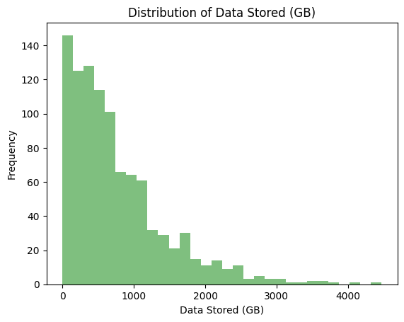

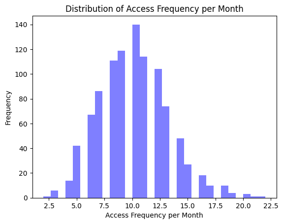

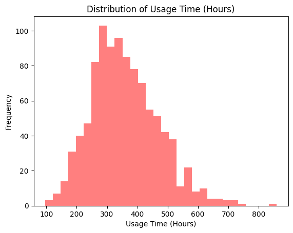

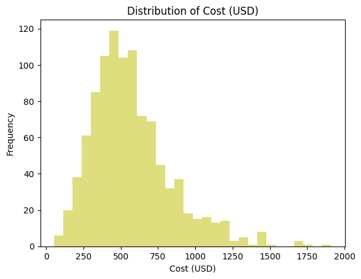

```python
import matplotlib.pyplot as plt

# Print the summary statistics of the numerical columns
print(df.describe())

# Print the counts of the categorical columns
for col in ['Customer_Type', 'Service', 'Region', 'Had_Support_Incidents']:
    print(df[col].value_counts())

# Plot the distribution of data stored
plt.hist(df['Data_Stored_GB'], bins=30, alpha=0.5, color='g')
plt.title('Distribution of Data Stored (GB)')
plt.xlabel('Data Stored (GB)')
plt.ylabel('Frequency')
plt.show()

# Plot the distribution of access frequency
plt.hist(df['Access_Frequency_per_Month'], bins=30, alpha=0.5, color='b')
plt.title('Distribution of Access Frequency per Month')
plt.xlabel('Access Frequency per Month')
plt.ylabel('Frequency')
plt.show()

# Plot the distribution of usage time
plt.hist(df['Usage_Time_Hours'], bins=30, alpha=0.5, color='r')
plt.title('Distribution of Usage Time (Hours)')
plt.xlabel('Usage Time (Hours)')
plt.ylabel('Frequency')
plt.show()

# Plot the distribution of cost
plt.hist(df['Cost_USD'], bins=30, alpha=0.5, color='y')
plt.title('Distribution of Cost (USD)')
plt.xlabel('Cost (USD)')
plt.ylabel('Frequency')
plt.show()
```

# 2. **Data Quality Assessment**:

Our dataset may have inconsistencies due to different data collection methods across our services and regions. Can you write a Python script to identify potential sources of error or bias in the data? How would you quantify the impact of these issues on our analysis?

```python
# Check for missing values
print(df.isnull().sum())

# If there are missing values, you might fill them with appropriate values
# For example, if 'Data_Stored_GB' has missing values, you might fill them with the median
# df['Data_Stored_GB'].fillna(df['Data_Stored_GB'].median(), inplace=True)

# Check for duplicates
print(df.duplicated().sum())

# If there are duplicates, you might choose to drop them
# df.drop_duplicates(inplace=True)

# Check for outliers using the IQR method
Q1 = df.quantile(0.25)
Q3 = df.quantile(0.75)
IQR = Q3 - Q1

# Define a condition for any value to be an outlier
outlier_condition = (df < (Q1 - 1.5 * IQR)) | (df > (Q3 + 1.5 * IQR))

# Print the number of outliers in each column
print(outlier_condition.sum())

# If there are outliers, you might choose to handle them in various ways
# For example, you might cap them at the 1st and 99th percentiles
for col in df.columns:
    if df[col].dtype in ['int64', 'float64']:
        lower = df[col].quantile(0.05)
        upper = df[col].quantile(0.95)
        df[col] = df[col].clip(lower, upper)

outlier_condition = (df < (Q1 - 1.5 * IQR)) | (df > (Q3 + 1.5 * IQR))

# Print the number of outliers in each column
print(outlier_condition.sum())
```

```
Customer_Type                 0
Service                       0
Region                        0
Data_Stored_GB                0
Access_Frequency_per_Month    0
Usage_Time_Hours              0
Cost_USD                      0
Had_Support_Incidents         0
dtype: int64
0
Access_Frequency_per_Month     9
Cost_USD                      42
Customer_Type                  0
Data_Stored_GB                45
Had_Support_Incidents          0
Region                         0
Service                        0
Usage_Time_Hours              14
dtype: int64
Access_Frequency_per_Month    0
Cost_USD                      0
Customer_Type                 0
Data_Stored_GB                0
Had_Support_Incidents         0
Region                        0
Service                       0
Usage_Time_Hours              0
dtype: int64
```

# 3. **Complex Data Segmentation**:

Can you segment the customers into different groups based on their usage patterns of our diverse services, their regional behavior, and their interaction with our support team? Can you develop a segmentation strategy that allows for customers to belong to multiple segments if they exhibit different behaviors in different contexts?

```python
from sklearn.cluster import KMeans

# Select the numerical columns
numerical_cols = ['Data_Stored_GB', 'Access_Frequency_per_Month', 'Usage_Time_Hours']
numerical_data = df[numerical_cols]

# Normalize the numerical data
normalized_data = (numerical_data - numerical_data.mean()) / numerical_data.std()

# Perform K-means clustering
kmeans = KMeans(n_clusters=3, random_state=0).fit(normalized_data)

# Add the cluster labels to the dataframe
df['Segment'] = kmeans.labels_

# Print the number of customers in each segment ### 3. sort the order of index to match below ###
print(df['Segment'].value_counts().sort_index())

# Print the mean values of the numerical columns for each segment
print(df.groupby('Segment')[numerical_cols].mean())
```

```
0    335
1    219
2    446
Name: Segment, dtype: int64
         Data_Stored_GB  Access_Frequency_per_Month  Usage_Time_Hours
Segment
0            527.182388                    9.540299        466.630373
1           1647.800652                   10.009132        331.110297
2            446.690986                   10.170404        289.513530
```

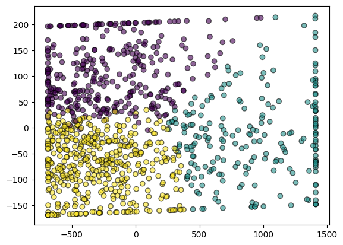

```python
from sklearn.decomposition import PCA

pca = PCA(n_components=2)
X = pca.fit_transform(df[numerical_cols])
plt.scatter(X[:, 0], X[:, 1], c=kmeans.labels_, edgecolor='k', alpha=0.6)
plt.show()
```

```python
!pip install scikit-fuzzy
```

```
     ━━━━━━━━━━━━━━━━━━━━━━━━━━━━━━━━━━━━━━ 994.0/994.0 kB 14.2 MB/s eta 0:00:00
  Preparing metadata (setup.py) ... done
```

```python
import skfuzzy as fuzz

# Select the numerical columns
numerical_cols = ['Data_Stored_GB', 'Access_Frequency_per_Month', 'Usage_Time_Hours']
numerical_data = df[numerical_cols]

# Normalize the numerical data
normalized_data = (numerical_data - numerical_data.mean()) / numerical_data.std()

# Transpose the data to fit the input format of the Fuzzy C-Means function
data_transposed = normalized_data.values.T

# Perform Fuzzy C-Means
cntr, u, u0, d, jm, p, fpc = fuzz.cluster.cmeans(data_transposed, c=3, m=2, error=0.005, maxiter=1000, init=None)

# Get the membership degrees for each customer and each cluster
u = u.T
for i in range(len(u)):
  max_p = max(u[i])
  for j in range(3):
    if abs(max_p-u[i][j])/max_p <= 0.1:
      u[i][j] = int(1)
    else:
      u[i][j] = int(0)


for i in range(3):
  df['Segment_{}'.format(i)] = u.T[i]


# Print the membership degrees of the first few customers
df.head()
```

[output not shown]

```python
from sklearn.decomposition import LatentDirichletAllocation

# Convert the categorical features to dummy variables

features = ['Customer_Type', 'Service', 'Region']
features_data = pd.get_dummies(df[features])

# Perform LDA
lda = LatentDirichletAllocation(n_components=3, random_state=0)
lda.fit(features_data)

# Get the topic (i.e., segment) distribution for each customer
topic_dist = lda.transform(features_data)

# Add the topic distribution to the dataframe
for i in range(lda.n_components):
    df[f'Segment_{i}'] = topic_dist[:, i]

# Print the first few rows of the dataframe
df.head()
```

```
      Customer_Type         Service         Region  Data_Stored_GB  \
0           startup  Compute Engine         Europe      198.264000
1        individual       Cloud Run   Asia-Pacific      251.098902
2        individual  Compute Engine  North America      415.016810
3  large_enterprise   Cloud Storage    Middle East      517.037433
4           startup  Compute Engine  South America      810.044204

   Access_Frequency_per_Month  Usage_Time_Hours    Cost_USD  \
0                           9        362.033274  373.240689
1                          12        446.619299  238.353287
2                          10        302.309742  363.301242
3                           8        396.663433  552.093476
4                           9        517.459648  537.921748

   Had_Support_Incidents  Segment  Segment_0  Segment_1  Segment_2
0                      0        2   0.110061   0.802706   0.087233
1                      0        0   0.579449   0.333066   0.087485
2                      1        2   0.087136   0.579524   0.333340
3                      0        0   0.091479   0.166658   0.741863
4                      1        0   0.098285   0.814515   0.087199
```

```python
multi_res = []
for i in df.itertuples():
  line = [i.Segment_0,i.Segment_1,i.Segment_2]
  max_p = max(line)
  for j in range(3):
    if abs(max_p-line[j])/max_p <= 0.2:
      line[j] = 1
    else:
      line[j] = 0
  multi_res.append(line)
multi_res = np.array(multi_res).T

for i in range(3):
  df['Segment_{}'.format(i)] = multi_res[i]

df.head()
```

|  | Customer_Type | Service | Region | Data_Stored_GB | Access_Frequency_per_Month | Usage_Time_Hours | Cost_USD | Had_Support_Incidents | Segment | Segment_0 | Segment_1 | Segment_2 |
| --- | --- | --- | --- | --- | --- | --- | --- | --- | --- | --- | --- | --- |
| 0 | startup | Compute Engine | Europe | 198.264000 | 9 | 362.033274 | 373.240689 | 0 | 2 | 0 | 1 | 0 |
| 1 | individual | Cloud Run | Asia-Pacific | 251.098902 | 12 | 446.619299 | 238.353287 | 0 | 0 | 1 | 0 | 0 |
| 2 | individual | Compute Engine | North America | 415.016810 | 10 | 302.309742 | 363.301242 | 1 | 2 | 0 | 1 | 0 |
| 3 | large_enterprise | Cloud Storage | Middle East | 517.037433 | 8 | 396.663433 | 552.093476 | 0 | 0 | 0 | 0 | 1 |
| 4 | startup | Compute Engine | South America | 810.044204 | 9 | 517.459648 | 537.921748 | 1 | 0 | 0 | 1 | 0 |

# 4. **Predictive Modeling with Uncertainty Quantification**:

Based on the segmented data, can you build a predictive model in Python that not only forecasts the future usage of our services for each customer segment, but also quantifies the uncertainty of these predictions? How would you incorporate different sources of uncertainty into your model?

```python
from sklearn.model_selection import train_test_split
from sklearn.ensemble import RandomForestRegressor
from sklearn.metrics import mean_squared_error
from sklearn.metrics import mean_absolute_error
# Select the features and the target

features = [ 'Access_Frequency_per_Month', 'Usage_Time_Hours', 'Data_Stored_GB', 'Segment_1', 'Segment_2', 'Segment_0'  ]
target = 'Cost_USD'

# Convert the categorical features to dummy variables
features_data = pd.get_dummies(df[features])

# Split the data into training and test sets
X_train, X_test, y_train, y_test = train_test_split(features_data, df[target], test_size=0.2, random_state=0)

# Baseline Model without Segment
model = RandomForestRegressor(n_estimators=100, random_state=0)


model.fit(X_train.drop(['Segment_1', 'Segment_2', 'Segment_0'], axis=1), y_train)
y_pred = model.predict(X_test.drop(['Segment_1', 'Segment_2', 'Segment_0'], axis=1))
rmse = np.sqrt(mean_squared_error(y_test, y_pred))

print('RMSE_withoutS:', rmse)

# Train a Random Forest Regressor
model = RandomForestRegressor(n_estimators=100, random_state=0)
model.fit(X_train, y_train)

# Make predictions on the test set
y_pred = model.predict(X_test)

# Calculate the RMSE
rmse = np.sqrt(mean_squared_error(y_test, y_pred))

print('RMSE_withS:', rmse)
```

```
RMSE_withoutS: 105.56125014888774
RMSE_withS: 89.57035180956602
```

```python
from sklearn.utils import resample

# Initialize an empty list to store the predictions from each bootstrap iteration
bootstrap_preds = []

# Perform 1000 bootstrap iterations
for i in range(1000):
    # Generate a bootstrap sample (i.e., a random sample with replacement)
    bootstrap_sample = resample(df, replace=True, random_state=i)

    # Split the bootstrap sample into a training set and a test set
    # (optional): remind people what's in your features (should not have numerical fields since u r doing dummy)
    X_train, X_test, y_train, y_test = train_test_split(pd.get_dummies(bootstrap_sample[features]), bootstrap_sample[target], test_size=0.2, random_state=0)

    # Train a Random Forest Regressor on the training set
    model = RandomForestRegressor(n_estimators=100, random_state=0)
    model.fit(X_train, y_train)

    # Make predictions on the test set and store them
    bootstrap_preds.append(model.predict(X_test))

# Convert the list of predictions into a 2D array
bootstrap_preds = np.array(bootstrap_preds)

# Calculate the mean and standard deviation of the predictions for each data point
pred_mean = bootstrap_preds.mean(axis=0)
pred_std = bootstrap_preds.std(axis=0)

# Print the first few predictions along with their uncertainties
for i in range(5):
    print(f'Prediction: {pred_mean[i]:.2f}, Uncertainty: {pred_std[i]:.2f}')
```

```
Prediction: 566.69, Uncertainty: 221.25
Prediction: 573.34, Uncertainty: 226.26
Prediction: 561.08, Uncertainty: 218.48
Prediction: 574.14, Uncertainty: 232.95
Prediction: 561.90, Uncertainty: 222.85
```

# 5. **Model Evaluation and Fairness Assessment**:

How would you evaluate the performance of your predictive model in the context of our business objectives? Can you write a Python script to calculate key performance metrics, including some that assess the fairness of your model across different customer types and regions? How would you address any fairness issues that you find?

```python
from sklearn.metrics import mean_absolute_error, r2_score

features = [ 'Access_Frequency_per_Month', 'Usage_Time_Hours', 'Data_Stored_GB', 'Segment_1', 'Segment_2', 'Segment_0'  ]
target = 'Cost_USD'

# Convert the categorical features to dummy variables
features_data = pd.get_dummies(df[features])

# Split the data into training and test sets
X_train, X_test, y_train, y_test = train_test_split(features_data, df[target], test_size=0.2, random_state=0)
model = RandomForestRegressor(n_estimators=100, random_state=0)
model.fit(X_train, y_train)

# Make predictions on the test set
y_pred = model.predict(X_test)

# # Calculate additional metrics
# mae = mean_absolute_error(y_test, y_pred)
# r2 = r2_score(y_test, y_pred)

# print('MAE:', mae)
# print('R2:', r2)

# Perform hyperparameter tuning
from sklearn.model_selection import GridSearchCV

# Define the parameter grid
param_grid = {
    'n_estimators': [50, 100, 200],
    'max_depth': [None, 10, 20, 30],
    'min_samples_split': [2, 5, 10]
}

# Perform grid search
grid_search = GridSearchCV(RandomForestRegressor(random_state=0), param_grid, cv=5, scoring='r2')
grid_search.fit(X_train, y_train)

# Print the best parameters and the best score
print('Best parameters:', grid_search.best_params_)
print('Best score(R2):', grid_search.best_score_)
```

[output not shown]

```python
df_oneh = pd.get_dummies(df, columns=['Customer_Type', 'Service', 'Region'])
df_oneh = df_oneh.iloc[X_test.index]
# Calculate the RMSE for each customer type
for customer_type in df['Customer_Type'].unique():
    mask = df_oneh['Customer_Type_' + customer_type] == 1
    rmse = np.sqrt(mean_squared_error(y_test[mask], y_pred[mask]))
    print(f'RMSE for {customer_type}:', rmse)

# Calculate the RMSE for each region
for region in df['Region'].unique():
    mask = df_oneh['Region_' + region] == 1
    rmse = np.sqrt(mean_squared_error(y_test[mask], y_pred[mask]))
    print(f'RMSE for {region}:', rmse)

# Calculate the RMSE for each segment
for segment in range(3):
    mask = X_test['Segment_' + str(segment)] == 1
    rmse = np.sqrt(mean_squared_error(y_test[mask], y_pred[mask]))
    print('RMSE for {}:'.format('Segment_' + str(segment)), rmse)
```

```
RMSE for startup: 75.04663827577888
RMSE for individual: 99.6336021427358
RMSE for large_enterprise: 90.70900719500828
RMSE for Europe: 79.14989268824091
RMSE for Asia-Pacific: 109.02874530958044
RMSE for North America: 99.02182155179433
RMSE for Middle East: 88.63055556655279
RMSE for South America: 74.39919900756422
RMSE for Africa: 82.9621626167012
RMSE for Segment_0: 90.43725925899311
RMSE for Segment_1: 81.42965731034369
RMSE for Segment_2: 100.29392092236802
```

# 6. **Business Impact Analysis with Scenario Planning**:

Given the results of your predictive model, how would you translate these findings into actionable recommendations for our business? Can you develop a scenario planning framework that uses your model's predictions and uncertainties to evaluate the potential impact of different business decisions?